# Worldbank Education Analysis

Maximilian Frei

2025-01-20

## Introduction

This analysis explores relationships between indicators such as central government debt, labor force education levels, and pupil-teacher ratios using World Bank data. We are particular interested in these two research questions:

1. Do countries with **higher central government debt** as a percentage of GDP have a **lower percentage of labor force with basic education**?
2. Are countries with **higher percentage of labor force with basic education** able to maintain **lower pupil-teacher ratios**, and what impact might this have on **education quality**?

The dataset we’ve been provided is longitudinal:

- 25 countries
- 18 indicators
- yearly observations from 2000 to 2021

Countries are classified into **quantiles** based on their **average values** for specific indicators. For this analysis, we group countries by **income level, population size, and population density**.

| **Quantile** | Q1 | Q2 | Q3 | Q4 | Q5 |
| --- | --- | --- | --- | --- | --- |
| Prevalence of alcohol consumption | Very Low | Low | Medium | High | Very High |
| Share of basic education | Very Low | Low | Medium | High | Very High |
| Population density | - | Low | Medium | High | - |
| Population size | - | Low | Medium | High | - |
| Income level | - | Low | Medium | High | - |
| Prevalence of tobacco consumption | Very Low | Low | Medium | High | Very High |
| Surface area | Very Low | Low | Medium | High | Very High |

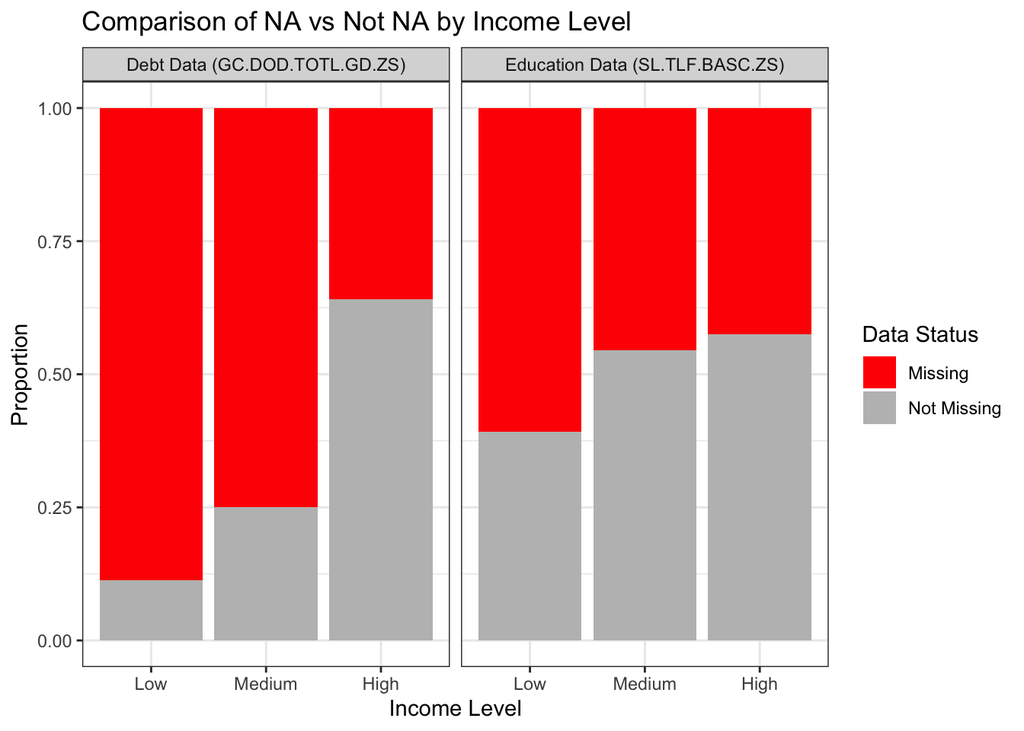

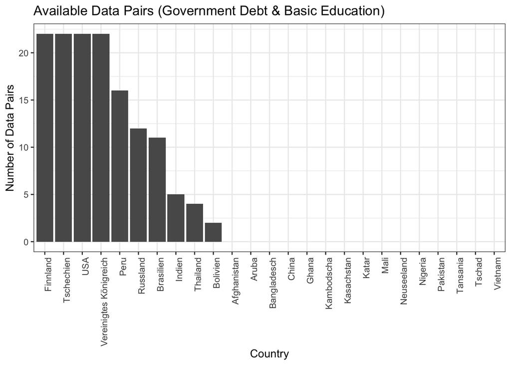

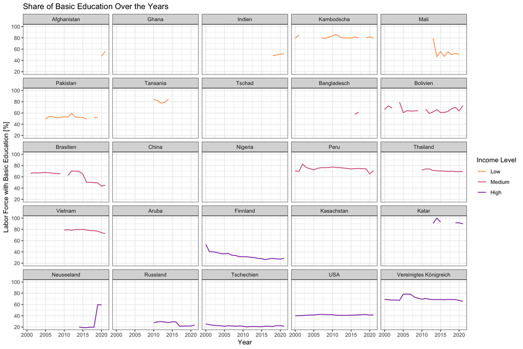

#### Data quality concerns

To mitigate these issues, we employ robust statistical techniques, including:

- **Robust Linear Models (RLMs)** for trend estimation, which are less sensitive to **outliers**.
- **Confidence Intervals** to provide insight into the **uncertainty of our estimates**.
- **Spearman correlation coefficients** to quantify relationships, as they are **resistant to non-normality** and **unevenly spaced values**.

#### Robust Linear Models

Traditional **Ordinary Least Squares (OLS)** estimates regression coefficients by minimizing the sum of squared residuals:

$$\min_{\beta} \sum_{i=1}^{n} (y_i - X_i \beta)^2$$

This approach provides **BLUE (Best Linear Unbiased Estimators)** under the **Gauss-Markov theorem**, but relies on the assumption that residuals are **normally distributed**. Given the inconsistencies in our dataset, this assumption is likely invalid. While OLS estimates remain **unbiased** but may become less efficient, potentially affecting the reliability of **confidence intervals and hypothesis tests**.

To address this, we use **Robust Linear Models (RLMs)**, specifically M-estimators, as implemented in `MASS::rlm()`. These models apply **Iteratively Reweighted Least Squares (IRLS)**, assigning smaller weights to outliers. Instead of minimizing squared residuals, RLMs use **alternative loss functions** that reduce the impact of extreme values.

In our analysis, we use the default psi function, **psi.huber**, which is based on **Huber’s loss function**:

$$L_{\delta}(r) =
\begin{cases}
\frac{1}{2} r^2 & \text{for } |r| \leq \delta, \\
\delta (|r| - \frac{1}{2} \delta) & \text{for } |r| > \delta.
\end{cases}$$

where:

- $r$ is the **residual** $y_i - X_i \beta$
- $\delta$ is the **threshold parameter** (default in R: **1.345**)

This method ensures **small residuals** behave like **OLS**, while **large residuals** have **reduced influence**, making RLMs more resistant to **outliers and non-normal residual distributions**.

#### Confidence Intervals

By default, `geom_smooth(method = MASS::rlm)` displays confidence intervals. However, unlike **ordinary least squares (OLS)**, `MASS::rlm()` does **not automatically provide standard errors**, as robust regression does not make the same assumptions about variability in the data.

The confidence intervals shown in `geom_smooth()` are based on an **approximation** rather than **true robust standard errors**. Specifically, `ggplot2` estimates confidence intervals using the **standard formula for least squares regression**:

$$CI = \hat{y} \pm t_{\alpha/2, df} \cdot SE(\hat{y})$$

where:

- $\hat{y}$ is the **predicted value** from the robust regression model
- $SE(\hat{y})$ is the **standard error of the fitted values**, approximated using **local smoothing techniques**
- $t_{\alpha/2, df}$ is the **critical t-value** for a 95% confidence level

Since robust regression methods like `rlm()` do not inherently calculate standard errors, the confidence intervals shown by `geom_smooth()` are **only an approximation**. A more rigorous approach would involve computing **robust standard errors manually** using the **Huber-White sandwich estimator** or **bootstrapping techniques**.

For simplicity, we retain the default confidence bands provided by `geom_smooth()`, while acknowledging that they do not fully account for the robustness adjustments of `rlm()`.

#### Spearman Correlation

The **Spearman correlation coefficient** measures the **monotonic relationship** between two variables. Unlike **Pearson correlation**, which captures only **linear relationships**, Spearman correlation assesses whether as one variable increases, the other tends to increase or decrease in a consistent order.

$$\rho = 1 - \frac{6 \sum d_i^2}{n(n^2 - 1)}$$
where:

- $d_i$ is the difference between the ranks of the corresponding values of the two variables
- $n$ is the number of observations

Since **Spearman correlation** operates on **ranked data**, it is **less sensitive to outliers and non-normal distributions**, making it particularly useful given the data quality concerns in our analysis.

### 1 Central Government Debt and Labor Force Education

We now examine whether countries with **higher central government debt (as % of GDP)** have **lower percentages of labor force with basic education**.

To visualize the general relationship, we plot a scatter plot with a robust linear model trend line.

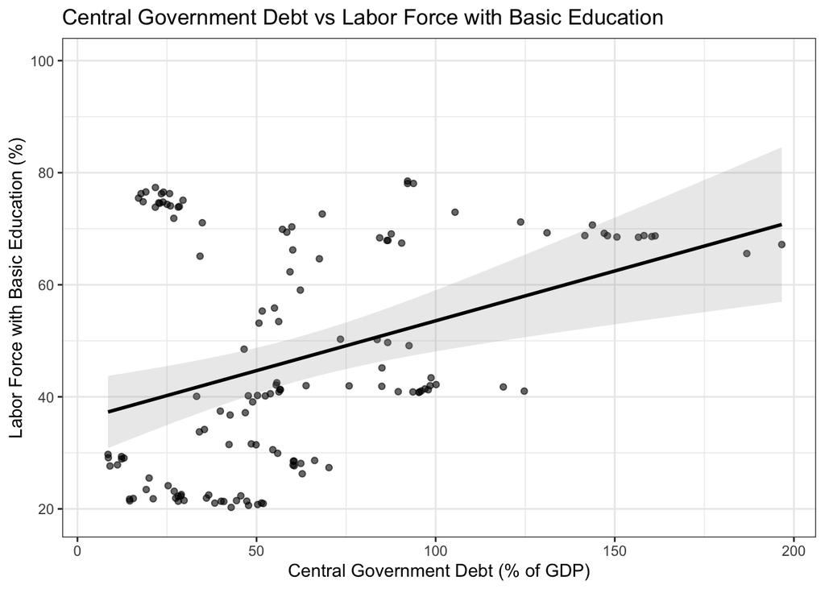

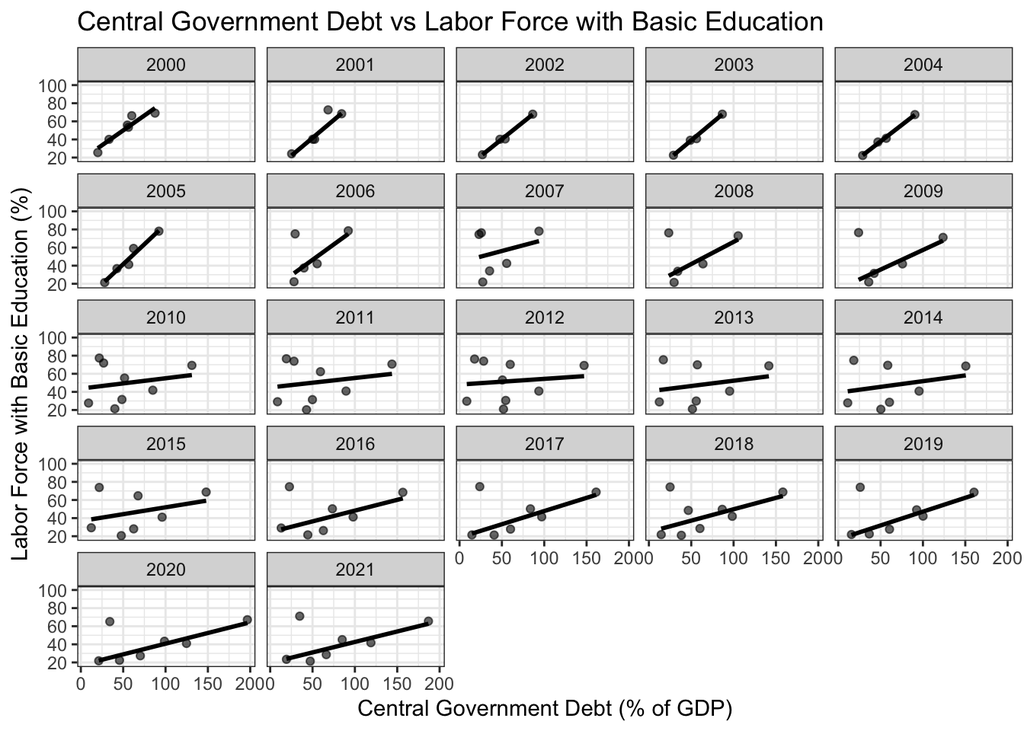

### Interpretation

At first glance, there appears to be a **positive relationship** between central government debt and labor force education over time. However, due to the high proportion of missing data, further investigation is required.

Analyzing this relationship by income levels is a logical next step, as income significantly impacts a country’s ability to invest in education and manage debt. This approach can reveal how economic disparities influence the correlation and highlight potential structural inequalities.

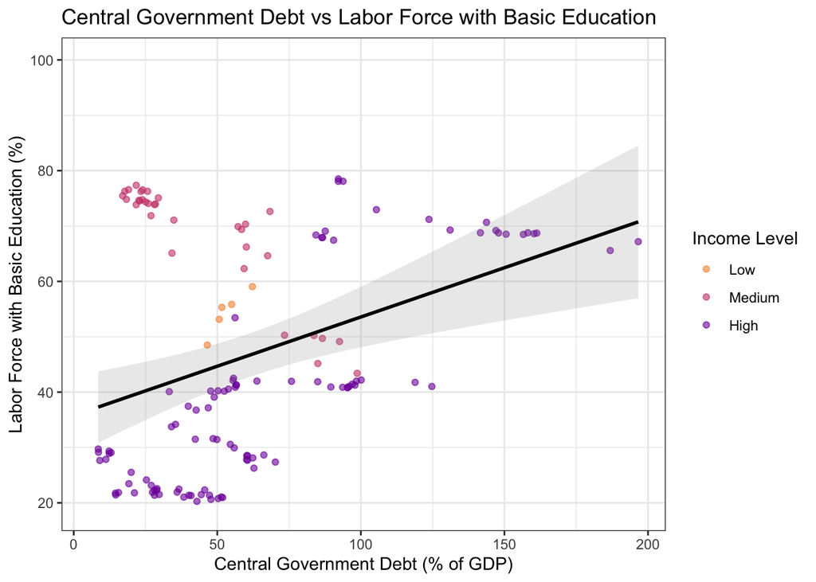

We observe a distinct clustering of data points among **medium-income countries**, which appear to exhibit **opposite trends**. To better visualize these relationships, we will create **faceted plots** for each income level, allowing for a clearer comparison between subgroups.

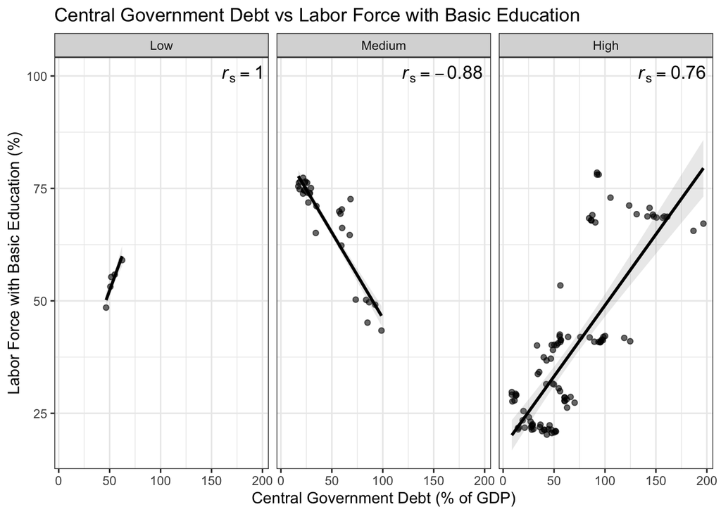

Due to the **significant lack of data** for **low-income countries**, we are unable to draw any meaningful conclusions for this group.

Interestingly, **medium- and high-income countries** exhibit **completely opposite trends** in the relationship between **debt and labor force education**. To explore potential influencing factors and gain deeper insights into **shared characteristics**, we further segment countries **by population size**.

In the **correlation matrix** below, **grey tiles indicate** cases where **fewer than 10 data pairs** are available, highlighting areas with limited data reliability.

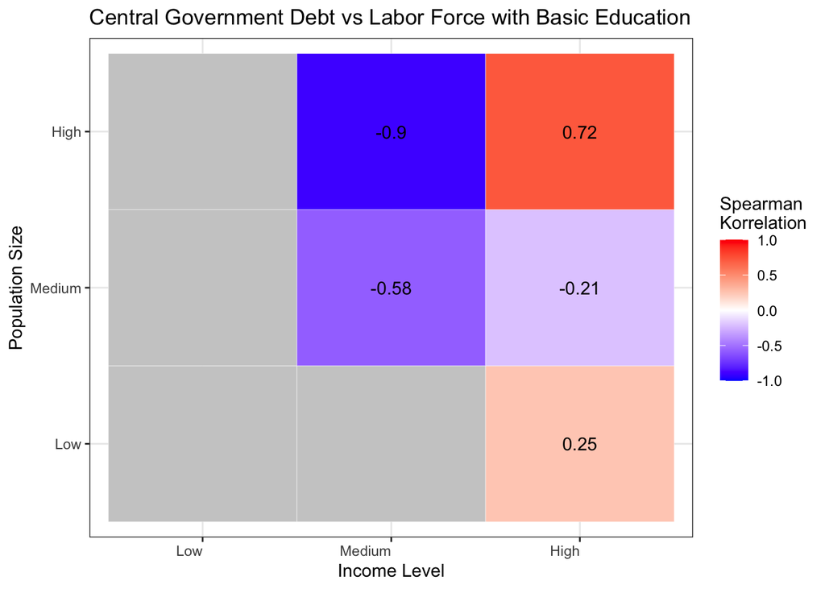

#### Further Questions and Interpretations:

- In **medium-income countries**, the negative correlation between **debt and labor force education** strengthens as **population size increases**.
- This pattern is **not observed** in **high-income countries**, where a strong relationship is only evident in **large-population nations**.
- The **overall positive correlation** may be influenced by the **disproportionate representation** of **high-income, high-population countries** in the dataset, potentially skewing the results.

### Conclusion

1. **Do countries with higher central government debt as a percentage of GDP have a lower percentage of labor force with basic education?**

While our initial hypothesis suggested a **negative relationship**, the data instead reveals an **overall positive correlation** between **debt and labor force education**. However, this relationship is **not uniform** and varies significantly based on **income level and population size**. These findings highlight the need for a **more nuanced approach**, as structural and economic factors likely play a crucial role in shaping this connection.

### **2. Labor Force Education and Pupil-Teacher Ratios**

To begin, we examine the **overall relationship** between **basic education levels** and **pupil-teacher ratios** to identify any broad trends before diving into more detailed subgroup analyses.

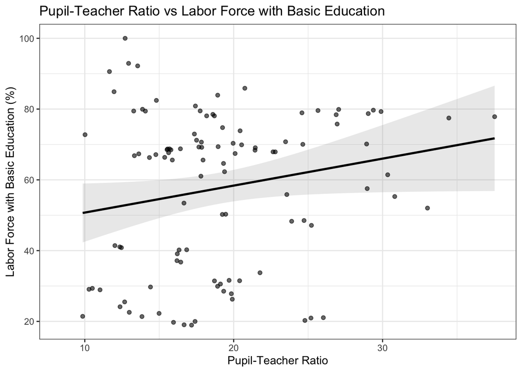

We observe a **weaker but still positive relationship** between **basic education levels and pupil-teacher ratios**.

The **pupil-teacher ratio** serves as an **indicator of available educational resources**, with **higher ratios suggesting limited resources**, as fewer teachers are available per student.

To further investigate this relationship, we analyze it **by population density**, as sparsely populated or remote regions may face **greater challenges in allocating educational resources** compared to **densely populated areas**, where resource distribution may be more efficient.

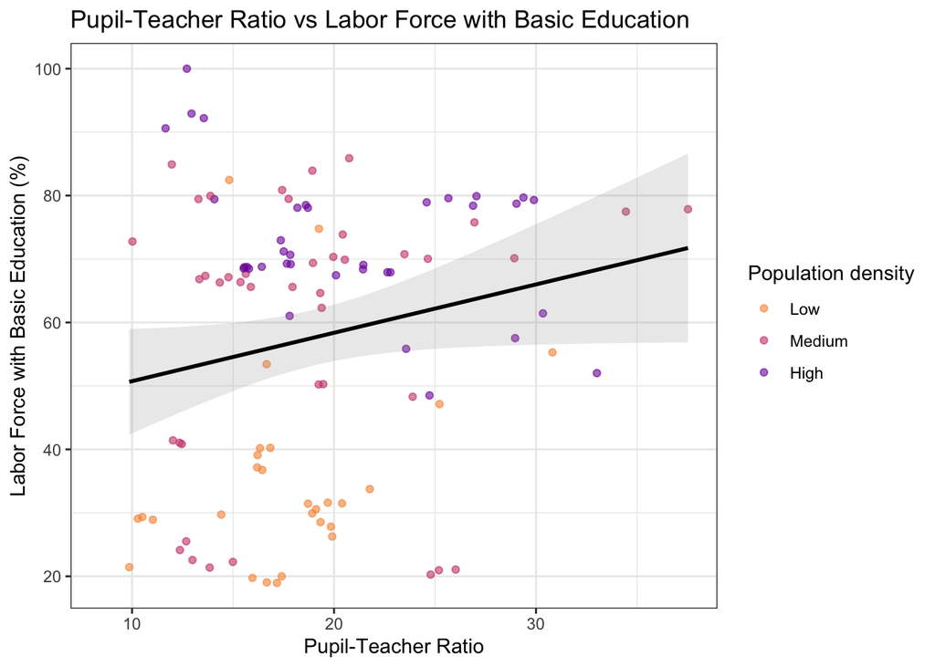

#### First Impressions:

- **Densely populated countries** tend to have **higher education quality**.
- **Sparsely populated countries** generally have **lower pupil-teacher ratios**.
- **Variability in education quality** decreases as **pupil-teacher ratios increase**.

To better highlight differences between **subgroups** and compute **individual Spearman correlation coefficients**, we will **facet the plot** by **population density**.

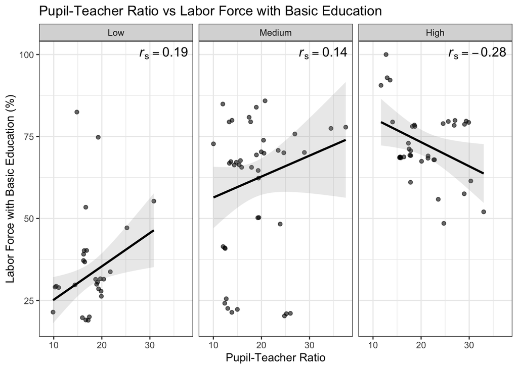

Contrary to intuition, a **lower pupil-teacher ratio** does not necessarily correspond to a **higher percentage of the labor force with basic education**, particularly in **sparsely populated countries**. This suggests that **other influencing factors** may play a more significant role. However, in **high-density populations**, the expected relationship becomes more apparent.

Assessing **education quality** is inherently complex, as its definition depends on the perspective taken and the weight assigned to various contributing factors.

For our analysis, we adopt an **economic perspective**, using **GDP per capita (USD)** as a **proxy for economic output**, which serves as a reasonable indicator of a country’s overall educational effectiveness and workforce potential.

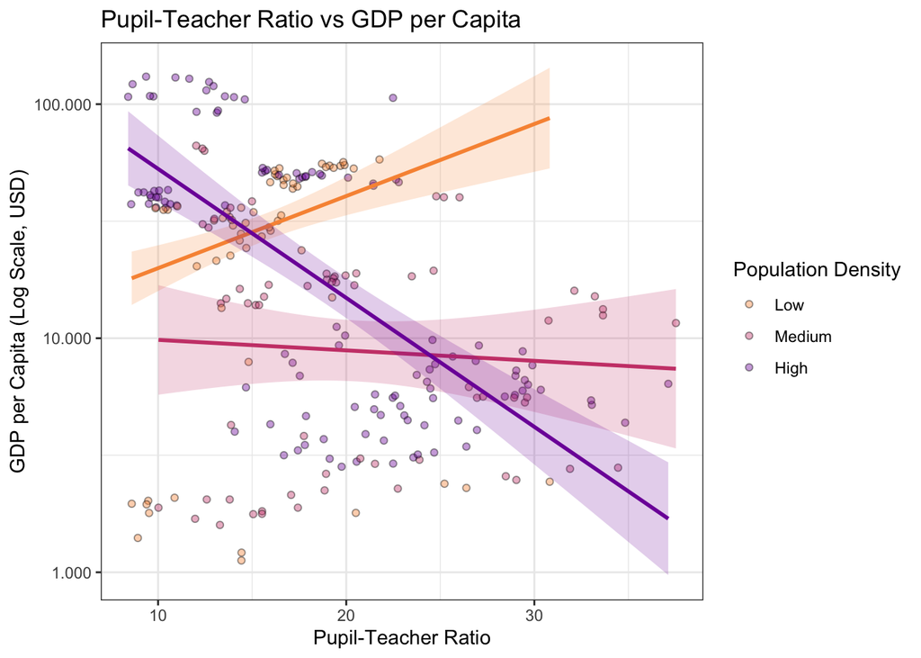

### Conclusion

2. Are countries with **higher percentage of labor force with basic education** able to maintain **lower pupil-teacher ratios**, and what impact might this have on **education quality**?

While one might expect that a lower pupil-teacher ratio would correlate with a higher percentage of the labor force having basic education, this pattern does not hold in sparsely populated countries. Instead, other factors appear to influence this relationship, suggesting that pupil-teacher ratios alone may not be a reliable indicator of educational resources in these regions. However, in countries with **high population density**, the expected relationship becomes more apparent.

- The anticipated effect emerges primarily in **densely populated countries**, where a lower pupil-teacher ratio aligns with a more educated workforce.
- In **sparsely populated countries**, pupil-teacher ratios do not necessarily reflect the level of educational investment or available resources, indicating that other structural or economic factors may play a more significant role.